# Preprocessing & EDA & A/B Testing

Nhóm

```r
library(tidyverse)
library(VIM)
library(janitor)
library(mice)
library(stringr)
library(knitr)
library(DT)
```

```r
data <- read_csv("fifa_eda_stats.csv", na = c("", "NA"))
data <- data |>
  clean_names()
```

# Tiền xử lý dữ liệu

## Làm sạch dữ liệu

- **Kiểm tra định dạng của dữ liệu**: Thay thế các chữ số bằng ký tự X, ta sẽ xem được định dạng của dữ liệu

  ```r
  currency_format <- data |>
    select(value, wage, release_clause, height, weight, joined, contract_valid_until) |>
    mutate(across(everything(), ~ifelse(is.na(.), ., gsub("[0-9]+", "X", .))))

  currency_format <- lapply(currency_format, unique) # Loại bỏ các định dạng trùng lặp
  currency_format
  ```

  ```
  ## $value
  ## [1] "€X.XM" "€XM"   "€X"    "€XK"
  ##
  ## $wage
  ## [1] "€XK" "€X"
  ##
  ## $release_clause
  ## [1] "€X.XM" "€XM"   NA      "€XK"
  ##
  ## $height
  ## [1] "X'X" NA
  ##
  ## $weight
  ## [1] "Xlbs" NA
  ##
  ## $joined
  ##  [1] "Jul X, X" "Aug X, X" "Sep X, X" NA         "Jan X, X" "Feb X, X"
  ##  [7] "Mar X, X" "Jun X, X" "Dec X, X" "Oct X, X" "May X, X" "Apr X, X"
  ## [13] "Nov X, X"
  ##
  ## $contract_valid_until
  ## [1] "X"        "Jun X, X" "Dec X, X" NA         "May X, X" "Jan X, X" "Oct X, X"
  ## [8] "Nov X, X" "Feb X, X"
  ```

  > *Nhận xét*
  > - Các cột `value`, `wage`, `release_clause` hiển thị các giá trị tiền tệ với đơn vị **Euro** (€) và các hậu tố **triệu** (M), **nghìn** (K)
  > - Cột `height` được định dạng kết hợp giữa **feet** và **inch**, trong khi cột `weight` chỉ chứa đơn vị **pound** (lbs).
  > - Cột `joined` chứa dữ liệu có đầy đủ thông tin về Ngày, Tháng, Năm. Ngoài ra, cột `contract_valid_until` có định dạng chỉ có thông tin về Năm
- **Xử lý dữ liệu các cột có đơn vị**:

  > *Hướng xử lý*
  > - Các cột dữ liệu tiền tệ (`wage`, `release_clause`, `value`) được làm sạch và chuẩn hóa về đơn vị triệu.
  > - Cột cân nặng (`weight`) của cầu thủ được chuyển đổi sang số nguyên sau khi xóa đơn vị **“lbs”**.
  > - Chiều cao (`height`) của cầu thủ được tính tổng số **inches** từ feet và inches.
  > - Các cột ngày (`joined`, `contract_valid_until`) được chuẩn hóa, thêm ngày cuối năm nếu chỉ có năm.

  ```r
  # Các cột biểu diễn dữ liệu tiền tệ được xử lý băng cách bỏ ký hiệu tiền tệ, chuẩn hóa về đơn vị ở phần triệu
  clean_currency <- function(column) {
    column <- str_remove(column, "€") # Loại bỏ ký hiệu tiền tệ
    # Đưa về đơn vị phần triệu
    column <- case_when(
      str_detect(column, "M") ~ as.numeric(str_remove(column, "M")), # Chuyển "M"
      str_detect(column, "K") ~ as.numeric(str_remove(column, "K")) / 1e3, # Chuyển "K"
      TRUE  ~ as.numeric(column)/1e6 #
      )
    return(column)
  }

  # Cột biểu diễn cân nặng của cầu thủ được xử lý bằng cách xóa đơn vị lbs
  clean_weight <- function(column){
    column <- str_remove(column, "lbs")
    column <- as.numeric(column)
    return(column)
  }

  # Cột biểu diễn chiều cao của cầu thủ được đưa về đơn vị inches
  clean_height <- function(feet_inches_value){
    parts <- str_split(string = feet_inches_value, pattern = "'")[[1]]
    feets <- as.numeric(parts[1])
    inches <- as.numeric(parts[2])
    total_inches <- (feets * 12) + inches
    return(total_inches)
  }

  # Cột biểu diễn ngày được đưa về định dạng phù hợp. Trường hợp, các dòng chỉ có thông tin Năm ở cột contract_valid_until, ta chọn ngày cuối cùng của năm
  clean_date <- function(date){
    date <- ifelse(nchar(date) == 4, paste("Dec 31,", date), date)
    date <- as.Date(date, format = "%b %d, %Y")
    return(date)
  }

     data <- data |>
    mutate(across(.cols = c("wage", "release_clause", "value"), ~clean_currency(.))) |>
    mutate(wage = wage * 1000) |>
    mutate(weight = clean_weight(weight)) |>
    mutate(height = sapply(X = height, FUN = clean_height)) |>
    mutate(across(.cols = c("joined", "contract_valid_until"), ~clean_date(.)))
  ```

- **Kiểm tra một số biến dạng phân loại**:

  ```r
  # Tổng quan các giá trị xuất hiện trong các biến phân loại
  categorical_columns <- data |>
    select(preferred_foot, international_reputation, position, body_type, work_rate,skill_moves, weak_foot)

  lapply(categorical_columns, unique)
  ```

  ```
  ## $preferred_foot
  ## [1] "Left"  "Right" NA
  ##
  ## $international_reputation
  ## [1]  5  4  3  2  1 NA
  ##
  ## $position
  ##  [1] "RF"  "ST"  "LW"  "GK"  "RCM" "LF"  "RS"  "RCB" "LCM" "CB"  "LDM" "CAM"
  ## [13] "CDM" "LS"  "LCB" "RM"  "LAM" "LM"  "LB"  "RDM" "RW"  "CM"  "RB"  "RAM"
  ## [25] "CF"  "RWB" "LWB" NA
  ##
  ## $body_type
  ##  [1] "Messi"               "C. Ronaldo"          "Neymar"
  ##  [4] "Lean"                "Normal"              "Courtois"
  ##  [7] "Stocky"              "PLAYER_BODY_TYPE_25" "Shaqiri"
  ## [10] "Akinfenwa"           NA
  ##
  ## $work_rate
  ##  [1] "Medium/ Medium" "High/ Low"      "High/ Medium"   "High/ High"
  ##  [5] "Medium/ High"   "Medium/ Low"    "Low/ High"      "Low/ Medium"
  ##  [9] "Low/ Low"       NA
  ##
  ## $skill_moves
  ## [1]  4  5  1  3  2 NA
  ##
  ## $weak_foot
  ## [1]  4  5  3  2  1 NA
  ```

  ```r
  # Những cầu thủ có vóc dáng là tên riêng
  outlier_body_types <- data |>
    select(name, body_type) |>
    filter(!(body_type %in% c("Lean", "Normal", "Stocky", NA)))

  outlier_body_types
  ```

  ```
  ## # A tibble: 7 × 2
  ##   name              body_type
  ##   <chr>             <chr>
  ## 1 L. Messi          Messi
  ## 2 Cristiano Ronaldo C. Ronaldo
  ## 3 Neymar Jr         Neymar
  ## 4 T. Courtois       Courtois
  ## 5 M. Salah          PLAYER_BODY_TYPE_25
  ## 6 X. Shaqiri        Shaqiri
  ## 7 A. Akinfenwa      Akinfenwa
  ```

  > *Nhận xét*
  > - Cột `body_type`: Cột này thể hiện vóc dáng của cầu thủ với 3 giá trị là: *Lean, Normal và Stocky*. Tuy nhiên, một số giá trị bất thường như tên riêng của cầu thủ *(Messi, C. Ronaldo)* cũng xuất hiện trong cột này, khả năng cao là lỗi dữ liệu.
  > - Cột `work_rate`: chứa 9 giá trị khác nhau, được cấu thành từ 2 phần, phân tách bởi dấu “/”. Phần đầu mô tả xu hướng hành vi của cầu thủ trong các tình huống tấn công, trong khi phần thứ hai mô tả xu hướng trong các tình huống phòng thủ. Mỗi phần có 3 cấp độ: High, Medium, Low; tạo thành 9 tổ hợp khác nhau.
  > - Các vị trí của cầu thủ trong đội hình được chia thành 4 nhóm chính, tổng cộng 27 vị trí:
  >   - **Thủ môn (Goalkeeper)**:
  >     - GK: Thủ môn (Goalkeeper)
  >   - **Hậu vệ (Defender)**:
  >     - LB: Hậu vệ trái (Left Back) – Bảo vệ cánh trái.
  >     - RB: Hậu vệ phải (Right Back) – Bảo vệ cánh phải.
  >     - CB: Trung vệ (Center Back) – Vị trí phòng ngự trung tâm.
  >     - LCB: Trung vệ lệch trái (Left Center Back) - – Trung vệ lệch về bên trái.
  >     - RCB: Trung vệ lệch phải (Right Center Back) - Trung vệ lệch về bên phải.
  >     - LWB: Hậu vệ cánh trái tấn công (Left Wing Back) – Hậu vệ cánh trái có xu hướng dâng cao
  >     - RWB: Hậu vệ cánh phải tấn công (Right Wing Back) – Hậu vệ cánh phải có xu hướng dâng cao.
  >   - **Tiền vệ (Midfielder)**:
  >     - CM: Tiền vệ trung tâm (Central Midfielder) – Kiểm soát khu vực trung tuyến.
  >     - LCM: Tiền vệ trung tâm lệch trái (Left Central Midfielder) – Tiền vệ trung tâm thiên về bên trái.
  >     - RCM: Tiền vệ trung tâm lệch phải (Right Central Midfielder) – Tiền vệ trung tâm thiên về bên phải.
  >     - CDM: Tiền vệ phòng ngự (Central Defensive Midfielder) – Tập trung phòng ngự phía trước hàng hậu vệ.
  >     - LDM: Tiền vệ phòng ngự lệch trái (Left Defensive Midfielder) – Phòng ngự ở bên trái trung tuyến.
  >     - RDM: Tiền vệ phòng ngự lệch phải (Right Defensive Midfielder) – Phòng ngự ở bên phải trung tuyến.
  >     - CAM: Tiền vệ tấn công (Central Attacking Midfielder) – Tập trung tấn công khu vực trung tâm.
  >     - LAM: Tiền vệ tấn công lệch trái (Left Attacking Midfielder) – Tấn công ở phía bên trái.
  >     - RAM: Tiền vệ tấn công lệch phải (Right Attacking Midfielder) – Tấn công ở phía bên phải
  >     - LM: Tiền vệ cánh trái (Left Midfielder) – Hỗ trợ tấn công và phòng ngự cánh trái.
  >     - RM: Tiền vệ cánh phải (Right Midfielder) – Hỗ trợ tấn công và phòng ngự cánh phải.
  >   - **Tiền đạo (Forward)**:
  >     - ST: Tiền đạo cắm (Striker) - Chuyên ghi bàn ở trung tâm hàng công.
  >     - CF: Tiền đạo trung tâm (Center Forward) – Tiền đạo chơi ngay phía trước hàng tiền vệ.
  >     - LS: Tiền đạo lệch trái (Left Striker) – Chuyên tấn công biên trái.
  >     - RS: Tiền đạo lệch phải (Right Striker) – Chuyên tấn công biên phải.
  >     - LW: Cánh trái (Left Winger) – Chuyên tấn công biên trái.
  >     - RW: Cánh phải (Right Winger) – Chuyên tấn công biên phải.
  >     - LF: Tiền đạo cánh trái (Left Forward) – Tiền đạo hoạt động ở phía trái.
  >     - RF: Tiền đạo cánh phải (Right Forward) – Tiền đạo hoạt động ở phía phải.
- **Xử lý một số biến dạng phân loại**:

  > *Hướng xử lý*
  > - Phân chia 27 vị trí trong cột `position` thành 4 nhóm: Goalkeeper, Defender, Midielder, Forward
  > - Đưa các giá trị ngoại lại trong cột `body_types` vào các nhóm chuẩn
  > - Phân tách cột `work_rate` thành 2 cột: `attacking_work_rate` và `deffensive_work_rate`
  > - Các biến phân loại được đưa về dạng `factor`

  ```r
  # Chuyển các vị trí vào các nhóm chính
  position_groups <- c(
    GK = "Goalkeeper",
    LB = "Defender", RB = "Defender", CB = "Defender",
    LCB = "Defender", RCB = "Defender", LWB = "Defender", RWB = "Defender",
    CM = "Midfielder", LCM = "Midfielder", RCM = "Midfielder",
    CDM = "Midfielder", LDM = "Midfielder", RDM = "Midfielder",
    CAM = "Midfielder", LAM = "Midfielder", RAM = "Midfielder",
    LM = "Midfielder", RM = "Midfielder",
    ST = "Forward", CF = "Forward", LF = "Forward", RF = "Forward",
    LW = "Forward", RW = "Forward", SS = "Forward",
    LS = "Forward", RS = "Forward"
  )

  # Xử lý các giá trị ngoại lai trong cột body_type
  clean_body_type <- function(body_type){
    if(is.na(body_type)){
      return(NA)
    }
    switch(body_type,
           "Messi" = "Lean",
           "Neymar" = "Lean",
           "C. Ronaldo" = "Stocky",
           "Courtois" = "Normal",
           "Shaqiri" = "Normal",
           "Akinfenwa" = "Stocky",
           "PLAYER_BODY_TYPE_25" = "Normal",
           body_type)
    }

  data <- data |>
    mutate(position = position_groups[position]) |>
    mutate(body_type = sapply(body_type, clean_body_type)) |>
    separate(col = "work_rate", into = c("attacking_work_rate", "deffensive_work_rate"), sep = "/", remove = TRUE) |>
    mutate(deffensive_work_rate = trimws(deffensive_work_rate)) |>
    mutate(across(.cols = c("preferred_foot", "international_reputation", "position",
                            "body_type", "attacking_work_rate", "deffensive_work_rate",
                            "skill_moves", "weak_foot"), ~as.factor(.)))
  ```

## Dữ liệu khuyết

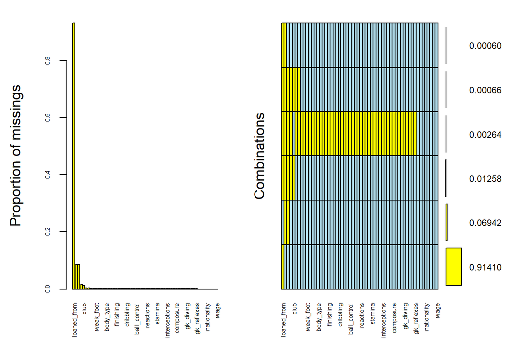

```
##
##  Variables sorted by number of missings:
##                  Variable       Count
##               loaned_from 0.930576152
##            release_clause 0.085901027
##                    joined 0.085296864
##      contract_valid_until 0.015873016
##                      club 0.013236667
##                  position 0.003295436
##             jersey_number 0.003295436
##            preferred_foot 0.002636349
##  international_reputation 0.002636349
##                 weak_foot 0.002636349
##               skill_moves 0.002636349
##       attacking_work_rate 0.002636349
##      deffensive_work_rate 0.002636349
##                 body_type 0.002636349
##                    height 0.002636349
##                    weight 0.002636349
##                  crossing 0.002636349
##                 finishing 0.002636349
##          heading_accuracy 0.002636349
##             short_passing 0.002636349
##                   volleys 0.002636349
##                 dribbling 0.002636349
##                     curve 0.002636349
##               fk_accuracy 0.002636349
##              long_passing 0.002636349
##              ball_control 0.002636349
##              acceleration 0.002636349
##              sprint_speed 0.002636349
##                   agility 0.002636349
##                 reactions 0.002636349
##                   balance 0.002636349
##                shot_power 0.002636349
##                   jumping 0.002636349
##                   stamina 0.002636349
##                  strength 0.002636349
##                long_shots 0.002636349
##                aggression 0.002636349
##             interceptions 0.002636349
##               positioning 0.002636349
##                    vision 0.002636349
##                 penalties 0.002636349
##                 composure 0.002636349
##                   marking 0.002636349
##           standing_tackle 0.002636349
##            sliding_tackle 0.002636349
##                 gk_diving 0.002636349
##               gk_handling 0.002636349
##                gk_kicking 0.002636349
##            gk_positioning 0.002636349
##               gk_reflexes 0.002636349
##                        id 0.000000000
##                      name 0.000000000
##                       age 0.000000000
##               nationality 0.000000000
##                   overall 0.000000000
##                 potential 0.000000000
##                     value 0.000000000
##                      wage 0.000000000
```

```r
aggr(data, sortVar = T, col = c('lightblue','yellow'), number = T, cex.number = 0.75, cex.axis = 0.5 )
```

```r
# Nhóm các câu lạc bộ có các cầu thủ bị khuyết dữ liệu ở cột release_clause, joined, contract_valid_until
clubs_missing_contract <- data |> filter(!is.na(club) & is.na(loaned_from) & is.na(joined) & is.na(contract_valid_until))
unique(clubs_missing_contract$club)
```

```
##  [1] "Rochdale"                      "Boyacá Chicó FC"
##  [3] "Notts County"                  "Brescia"
##  [5] "Hamilton Academical FC"        "Śląsk Wrocław"
##  [7] "Club Atlético Aldosivi"        "Everton"
##  [9] "Hobro IK"                      "HJK Helsinki"
## [11] "AS Béziers"                    "SV Mattersburg"
## [13] "Tranmere Rovers"               "Shanghai Greenland Shenhua FC"
## [15] "Itagüí Leones FC"              "NAC Breda"
## [17] "Malmö FF"                      "Carlisle United"
## [19] "VfB Stuttgart"                 "Dundee FC"
## [21] "Suwon Samsung Bluewings"       "Al Wehda"
## [23] "CD Palestino"                  "Albacete BP"
## [25] "Al Nassr"                      "TSV 1860 München"
## [27] "FC Admira Wacker Mödling"      "Grenoble Foot 38"
## [29] "Oldham Athletic"               "Hammarby IF"
## [31] "Miedź Legnica"                 "Jaguares de Córdoba"
## [33] "Bologna"                       "CD Antofagasta"
## [35] "Kristiansund BK"               "Al Raed"
## [37] "Deportes Iquique"              "FC Utrecht"
## [39] "Perugia"                       "Montpellier HSC"
## [41] "Gyeongnam FC"                  "Tiburones Rojos de Veracruz"
## [43] "Guizhou Hengfeng FC"
```

> **Hướng xử lý:**  
> - Phần dữ liệu khuyết trong cột `loaned_from` ta sẽ thay thế bằng giá trị `Not on loan` để thể hiện các cầu thủ không ở dạng mượn.  
> - Vì phần dữ liệu khuyết nhỏ nên ta có thể loại bỏ.

```r
# Xử lý dữ liệu khuyết ở cột loaned_from
data <- data |>
  mutate(loaned_from = ifelse(is.na(loaned_from), "Not on loan", loaned_from)) |>
  mutate(loaned_from = as.factor(loaned_from))

# Xóa phần dữ liệu khuyết
data <- na.omit(data)
```

```r
# Lưu dữ liệu đã được xử lý
write_csv(data, file = "cleaned_fifa_eda_stats.csv")
```

# EDA

```r
data <- read_csv('cleaned_fifa_eda_stats.csv')
datatable(
  head(data, 10),
  options = list(scrollX = TRUE, dom = 't')
)
```

|  | id | name | age | nationality | overall | potential | club | value | wage | preferred_foot | international_reputation | weak_foot | skill_moves | attacking_work_rate | deffensive_work_rate | body_type | position | jersey_number | joined | loaned_from | contract_valid_until | height | weight | crossing | finishing | heading_accuracy | short_passing | volleys | dribbling | … |
| --- | --- | --- | --- | --- | --- | --- | --- | --- | --- | --- | --- | --- | --- | --- | --- | --- | --- | --- | --- | --- | --- | --- | --- | --- | --- | --- | --- | --- | --- | --- |
| 1 | 158023 | L. Messi | 31 | Argentina | 94 | 94 | FC Barcelona | 110.5 | 565 | Left | 5 | 4 | 4 | Medium | Medium | Lean | Forward | 10 | 2004-07-01 | Not on loan | 2021-12-31 | 67 | 159 | 84 | 95 | 70 | 90 | 86 | 97 | … |
| 2 | 20801 | Cristiano Ronaldo | 33 | Portugal | 94 | 94 | Juventus | 77 | 405 | Right | 5 | 4 | 5 | High | Low | Stocky | Forward | 7 | 2018-07-10 | Not on loan | 2022-12-31 | 74 | 183 | 84 | 94 | 89 | 81 | 87 | 88 | … |
| 3 | 190871 | Neymar Jr | 26 | Brazil | 92 | 93 | Paris Saint-Germain | 118.5 | 290 | Right | 5 | 5 | 5 | High | Medium | Lean | Forward | 10 | 2017-08-03 | Not on loan | 2022-12-31 | 69 | 150 | 79 | 87 | 62 | 84 | 84 | 96 | … |
| 4 | 193080 | De Gea | 27 | Spain | 91 | 93 | Manchester United | 72 | 260 | Right | 4 | 3 | 1 | Medium | Medium | Lean | Goalkeeper | 1 | 2011-07-01 | Not on loan | 2020-12-31 | 76 | 168 | 17 | 13 | 21 | 50 | 13 | 18 | … |
| 5 | 192985 | K. De Bruyne | 27 | Belgium | 91 | 92 | Manchester City | 102 | 355 | Right | 4 | 5 | 4 | High | High | Normal | Midfielder | 7 | 2015-08-30 | Not on loan | 2023-12-31 | 71 | 154 | 93 | 82 | 55 | 92 | 82 | 86 | … |
| 6 | 183277 | E. Hazard | 27 | Belgium | 91 | 91 | Chelsea | 93 | 340 | Right | 4 | 4 | 4 | High | Medium | Normal | Forward | 10 | 2012-07-01 | Not on loan | 2020-12-31 | 68 | 163 | 81 | 84 | 61 | 89 | 80 | 95 | … |
| 7 | 177003 | L. Modrić | 32 | Croatia | 91 | 91 | Real Madrid | 67 | 420 | Right | 4 | 4 | 4 | High | High | Lean | Midfielder | 10 | 2012-08-01 | Not on loan | 2020-12-31 | 68 | 146 | 86 | 72 | 55 | 93 | 76 | 90 | … |
| 8 | 176580 | L. Suárez | 31 | Uruguay | 91 | 91 | FC Barcelona | 80 | 455 | Right | 5 | 4 | 3 | High | Medium | Normal | Forward | 9 | 2014-07-11 | Not on loan | 2021-12-31 | 72 | 190 | 77 | 93 | 77 | 82 | 88 | 87 | … |
| 9 | 155862 | Sergio Ramos | 32 | Spain | 91 | 91 | Real Madrid | 51 | 380 | Right | 4 | 3 | 3 | High | Medium | Normal | Defender | 15 | 2005-08-01 | Not on loan | 2020-12-31 | 72 | 181 | 66 | 60 | 91 | 78 | 66 | 63 | … |
| 10 | 200389 | J. Oblak | 25 | Slovenia | 90 | 93 | Atlético Madrid | 68 | 94 | Right | 3 | 3 | 1 | Medium | Medium | Normal | Goalkeeper | 1 | 2014-07-16 | Not on loan | 2021-12-31 | 74 | 192 | 13 | 11 | 15 | 29 | 13 | 12 | … |

## Giá trị lớn nhất, nhỏ nhất, trung bình, trung vị, độ lệch chuẩn

```r
stats <- data |> summarise(across(c("overall", "potential", "value", "wage"),
                                       list(gtnn = min, gtln = max, tv = median,
                                            tb = mean, dlc = sd)))
stats_cleaned <- stats |> gather(ten, gt) |>
  separate(ten, into = c("bien", "tk"), sep = "_") |>
  spread(tk, gt) |>
  dplyr::select(bien, gtnn, gtln, tv, tb, dlc) |>  mutate(across(c(gtnn, gtln, tv, tb, dlc), ~ round(.x, 2)))
```

```r
kable(stats_cleaned)
```

| bien | gtnn | gtln | tv | tb | dlc |
| --- | --- | --- | --- | --- | --- |
| overall | 46.00 | 94.0 | 66.00 | 66.16 | 7.01 |
| potential | 48.00 | 95.0 | 71.00 | 71.14 | 6.15 |
| value | 0.01 | 118.5 | 0.68 | 2.44 | 5.72 |
| wage | 1.00 | 565.0 | 3.00 | 9.62 | 22.26 |

## Số câu lạc bộ và quốc gia

```r
num_clubs <- length(unique(data$club))
num_countries <- length(unique(data$nationality))
sprintf("Số câu lạc bộ: %d, Số quốc gia: %d", num_clubs, num_countries)
```

```
## [1] "Số câu lạc bộ: 651, Số quốc gia: 161"
```

## Histogram cho chỉ số Overall

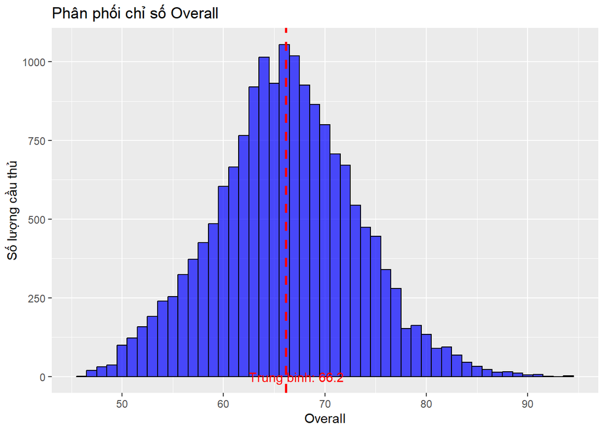

```r
ggplot(data, aes(x = overall)) +
  geom_histogram(binwidth = 1, fill = "blue", color = "black", alpha = 0.7) +
  labs(title = "Phân phối chỉ số Overall", x = "Overall", y = "Số lượng cầu thủ") +
  geom_vline(aes(xintercept = mean(data$overall)), color = "red", linetype = "dashed", linewidth = 1) +
  annotate(
    "text", x = (mean(data$overall) + 1), y = 0,
    label = paste0("Trung binh: ", round(mean(data$overall), 1)),
    color = "red", hjust = 0.5
  )
```

Biểu đồ cho thấy phân phối của chỉ số Overall có dạng hình chuông, tập trung chủ yếu xung quanh giá trị trung bình 66.2. Điều này cho thấy một phân phối gần giống với phân phối chuẩn

## Histogram cho chỉ số Potential

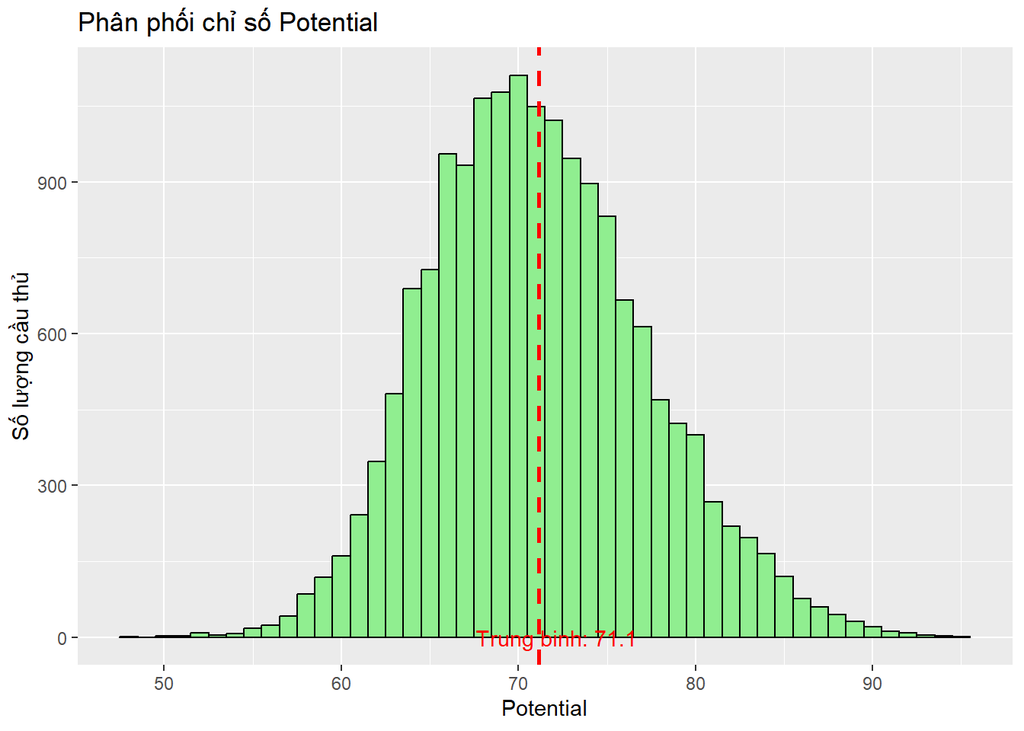

```r
ggplot(data, aes(x = potential)) +
  geom_histogram(binwidth = 1, fill = "lightgreen", color = "black", alpha = 1) +
  labs(title = "Phân phối chỉ số Potential", x = "Potential", y = "Số lượng cầu thủ") +
  geom_vline(aes(xintercept = mean(data$potential)), color = "red", linetype = "dashed", linewidth = 1) +
  annotate(
    "text", x = (mean(data$potential) + 1), y = 0,
    label = paste0("Trung binh: ", round(mean(data$potential), 1)),
    color = "red", hjust = 0.5
  )
```

Tương tự như Overall, biều đồ cho thấy phân phối của Potential gần giống phân phối chuẩn với trung bình 71.1

## Histogram cho tuổi cầu thủ

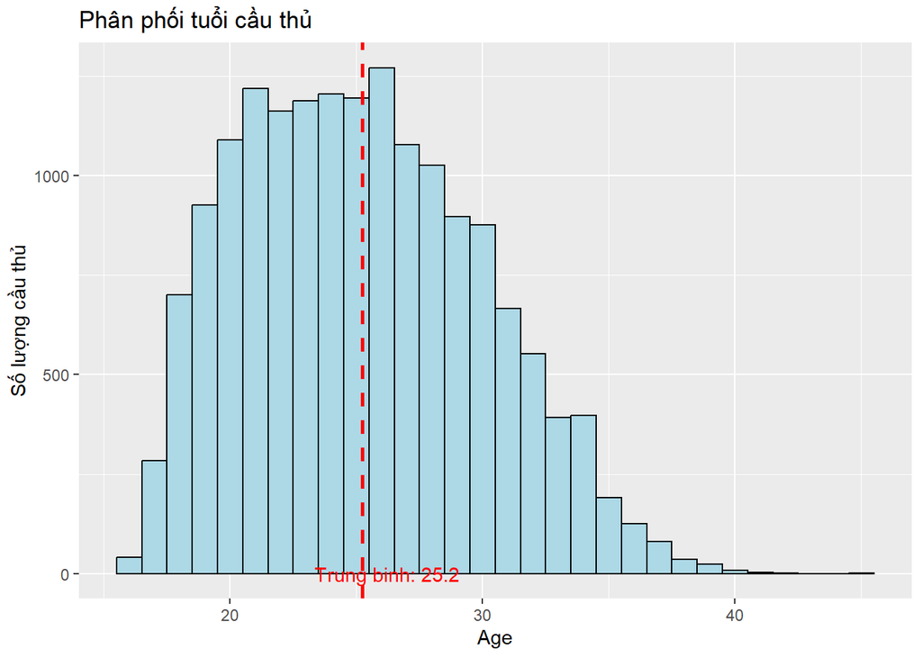

```r
ggplot(data, aes(x = age)) +
  geom_histogram(binwidth = 1, fill = "lightblue", color = "black", alpha = 1) +
  labs(title = "Phân phối tuổi cầu thủ", x = "Age", y = "Số lượng cầu thủ") +
  geom_vline(aes(xintercept = mean(data$age)), color = "red", linetype = "dashed", linewidth = 1) +
  annotate(
    "text", x = (mean(data$age) + 1), y = 0,
    label = paste0("Trung binh: ", round(mean(data$age), 1)),
    color = "red", hjust = 0.5
  )
```

Biểu đồ có hình dạng gần giống với phân phối chuẩn, với trung bình 25.2 tuổi. Có một số ít cầu thủ có độ tuổi lớn hơn 35, tạo nên phần đuôi bên phải của biểu đồ.

## Histogram cho giá trị thị trường

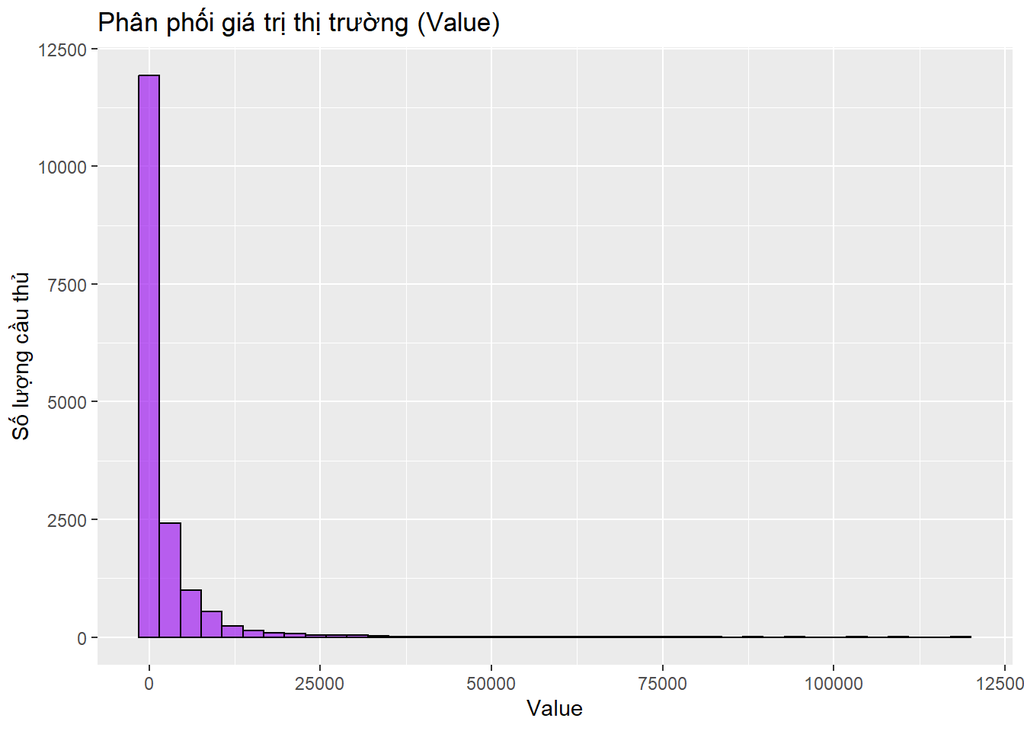

```r
data_change_value <- data |> mutate(value = value * 1000)
ggplot(data_change_value, aes(x = value)) +
  geom_histogram(fill = "purple", color = "black", alpha = 0.7, bins = 40) +
  labs(title = "Phân phối giá trị thị trường (Value)", x = "Value", y = "Số lượng cầu thủ")
```

Biều đồ có sự lệch phải, cho thấy có rất nhiều cầu thủ có giá trị dưới 1 triệu euro.

## Scatter plot giữa Overall và Wage

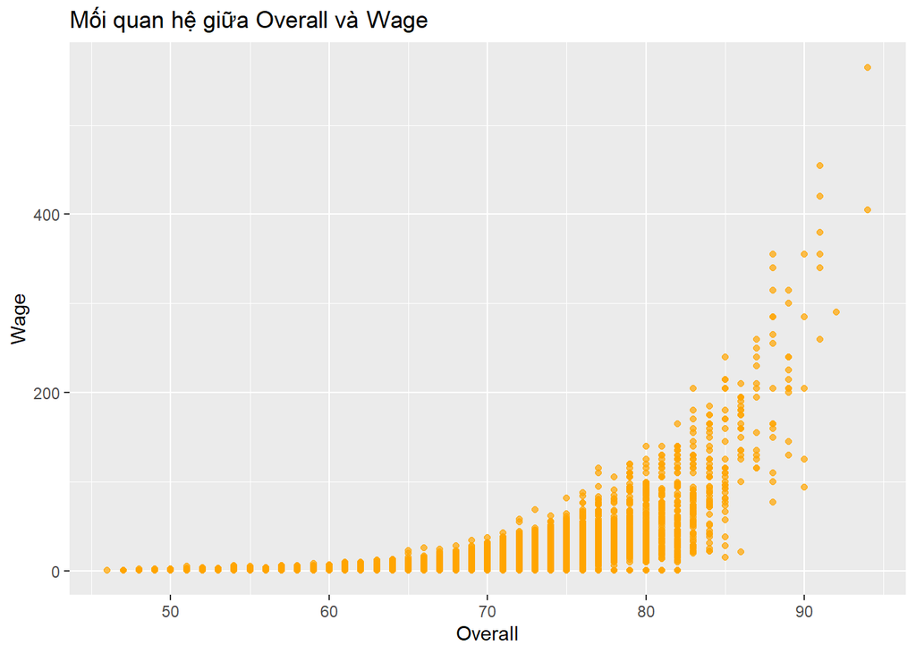

```r
ggplot(data, aes(x = overall, y = wage)) +
  geom_point(alpha = 0.7, color = "orange") +
  labs(title = "Mối quan hệ giữa Overall và Wage", x = "Overall", y = "Wage")
```

Các điểm dữ liệu có xu hướng tăng dần từ trái sang phải, cho thấy mối quan hệ dương giữa Overall và Wage. Nói cách khác, khi chỉ số Overall tăng lên thì mức lương cũng có xu hướng tăng theo. Tuy nhiên mối quan hệ này không hoàn toàn tuyến tính, ban đầu, khi chỉ số Overall tăng, mức lương tăng khá chậm, đến khi chỉ số Overall đạt một ngưỡng nhất định, mức lương tăng nhanh hơn.

## Scatter plot giữa giá trị chuyển nhượng và chi phí giải phóng hợp đồng

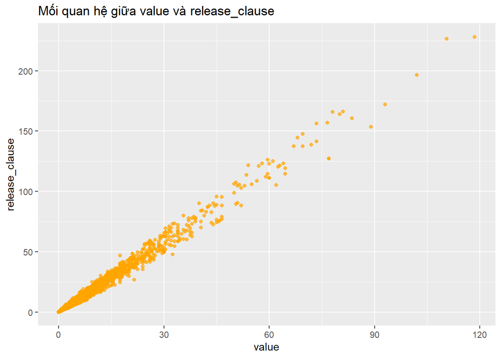

```r
ggplot(data, aes(x = value, y = release_clause)) +
  geom_point(alpha = 0.7, color = "orange") +
  labs(title = "Mối quan hệ giữa value và release_clause", x = "value", y = "release_clause")
```

Value và release_clause có mối quan hệ gần như tuyến tính, ta cũng có thể thấy rằng release_clause thường cao hơn nhiều so với value. Điều này có thể hiểu rằng các câu lạc bộ muốn giữ chân cầu thủ của mình nên đưa ra chi phí giải phóng hợp đồng rất cao.

## Các cầu thủ có Overall, Potential, Wage, Value cao nhất theo từng vị trí

```r
# Xử lý tên cầu thủ
get_clean_name <- function(x) {
  # Loại bỏ ký tự không hợp lệ
  gsub("[^[:print:]]", "", x)
}

# Tìm cầu thủ có chỉ số cao nhất theo từng tiêu chí cho từng vị trí
top_players <- data |>
  filter(position %in% c("Forward", "Midfielder", "Defender", "Goalkeeper")) |>
  group_by(position) |>
  summarise(
    overall_best = get_clean_name(name[which.max(overall)]),
    overall_value = max(overall, na.rm = TRUE),
    potential_best = get_clean_name(name[which.max(potential)]),
    potential_value = max(potential, na.rm = TRUE),
    wage_best = get_clean_name(name[which.max(wage)]),
    wage_value = max(wage, na.rm = TRUE),
    value_best = get_clean_name(name[which.max(value)]),
    value_value = max(value, na.rm = TRUE)
  )

kable(
  top_players,
  col.names = c(
    "position", "highest_overall", "overall",
    "highest_potential", "potential",
    "highest_wage", "wage",
    "highest_value", "value"
  ),
  format = "pipe"
)
```

| position | highest_overall | overall | highest_potential | potential | highest_wage | wage | highest_value | value |
| --- | --- | --- | --- | --- | --- | --- | --- | --- |
| Defender | Sergio Ramos | 91 | S. Umtiti | 92 | Sergio Ramos | 380 | S. Umtiti | 57.0 |
| Forward | L. Messi | 94 | L. Messi | 94 | L. Messi | 565 | Neymar Jr | 118.5 |
| Goalkeeper | De Gea | 91 | De Gea | 93 | De Gea | 260 | De Gea | 72.0 |
| Midfielder | K. De Bruyne | 91 | K. Mbappé | 95 | L. Modrić | 420 | K. De Bruyne | 102.0 |

## Giá trị trung bình của Overall và Potential theo quốc gia

```r
summary_by_country <- data |>
  group_by(nationality) |>
  summarise(
    avg_overall = mean(overall),
    avg_potential = mean(potential),
    count = n()
  ) |> arrange(desc(count))

kable(head(summary_by_country, 10))
```

| nationality | avg_overall | avg_potential | count |
| --- | --- | --- | --- |
| England | 63.46576 | 69.82644 | 1475 |
| Germany | 66.08949 | 71.60035 | 1151 |
| Spain | 69.73306 | 74.47639 | 974 |
| France | 67.73857 | 73.32708 | 853 |
| Argentina | 68.52581 | 73.08043 | 833 |
| Brazil | 71.25127 | 73.19162 | 788 |
| Italy | 68.24352 | 72.23489 | 579 |
| Colombia | 65.22632 | 70.74211 | 570 |
| Japan | 62.46154 | 66.44396 | 455 |
| Netherlands | 67.57042 | 72.92488 | 426 |

## Giá trị trung bình của Overall và Potential theo câu lạc bộ

```r
summary_by_club <- data |>
  group_by(club) |>
  summarise(
    avg_overall = mean(overall),
    avg_potential = mean(potential),
    count = n()
  ) |> arrange(desc(avg_overall))

kable(head(summary_by_club, 10))
```

| club | avg_overall | avg_potential | count |
| --- | --- | --- | --- |
| Juventus | 82.28000 | 85.52000 | 25 |
| Napoli | 80.04167 | 83.62500 | 24 |
| Inter | 79.61905 | 81.38095 | 21 |
| Real Madrid | 78.24242 | 84.63636 | 33 |
| FC Barcelona | 78.03030 | 85.30303 | 33 |
| Milan | 77.54167 | 82.00000 | 24 |
| Paris Saint-Germain | 77.43333 | 83.56667 | 30 |
| Roma | 77.40000 | 82.04000 | 25 |
| Manchester United | 77.24242 | 82.66667 | 33 |
| SL Benfica | 77.07407 | 81.74074 | 27 |

Theo bảng tổng hợp, Juventus là câu lạc bộ có chỉ số trung bình cầu thủ cũng như tiềm năng là cao nhất, những cái tên còn lại trong top 10 lần lượt là Napoli, Inter, Real Madrid, FC Barcelona, Milan, Paris Saint-German, Roma, Manchester United và Benfica. Điều đặc biệt ta có thể nhận thấy là trong top 10 có đến 5 câu lạc bộ đến từ Ý.

## Số lượng cầu thủ theo vị trí

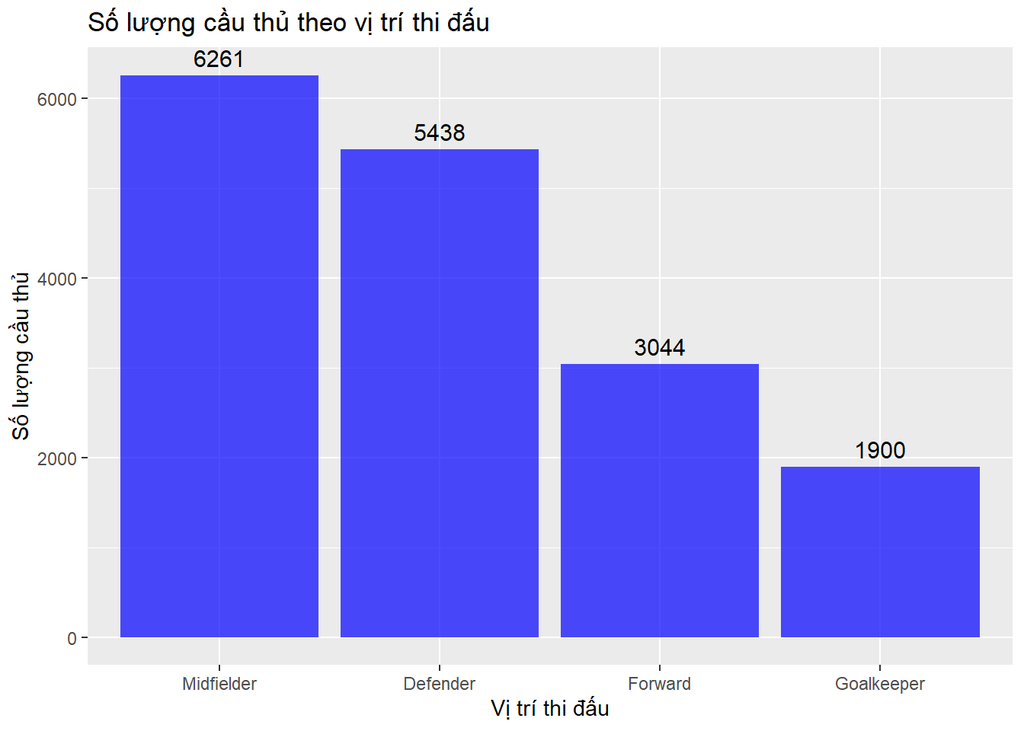

```r
position_count <- data |>
  count(position) |> arrange(desc(n))

ggplot(position_count, aes(x = reorder(position, -n), y = n)) +
  geom_bar(stat = "identity", fill = "blue", alpha = 0.7) +
  geom_text(aes(label = n), vjust = -0.5, color = "black", size = 4) +
  labs(title = "Số lượng cầu thủ theo vị trí thi đấu",
       x = "Vị trí thi đấu",
       y = "Số lượng cầu thủ")
```

Số lượng tiền vệ là nhiều nhất, kế đến lần lượt là hậu vệ và tiền đạo, thủ môn là ít nhất.

## Overall trung bình theo vị trí

```r
avg_overall_position <- data |>
  group_by(position) |>
  summarise(avg_overall = mean(overall)) |>
  arrange(desc(avg_overall))

kable(avg_overall_position)
```

| position | avg_overall |
| --- | --- |
| Midfielder | 66.45248 |
| Defender | 66.37164 |
| Forward | 66.25460 |
| Goalkeeper | 64.46316 |

Nhìn chung, chỉ số overall trung bình của các vị trí khá tương đồng, chỉ có thủ môn là thấp hơn hẳn.

## Tính trung bình lương theo vị trí

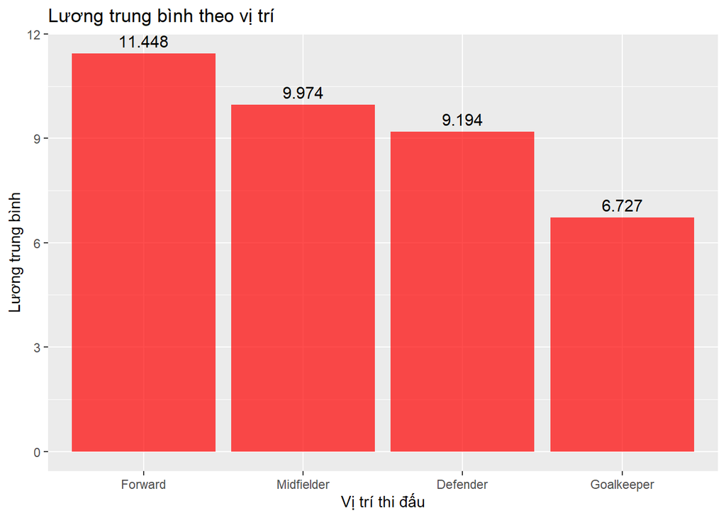

```r
avg_wage_position <- data |>
  group_by(position) |>
  summarise(avg_wage = mean(wage)) |>
  arrange(desc(avg_wage))

# Biểu đồ
ggplot(avg_wage_position, aes(x = reorder(position, -avg_wage), y = avg_wage)) +
  geom_bar(stat = "identity", fill = "red", alpha = 0.7) +
  geom_text(aes(label = round(avg_wage, 3)), vjust = -0.5, color = "black", size = 4) +
  labs(title = "Lương trung bình theo vị trí",
       x = "Vị trí thi đấu",
       y = "Lương trung bình")
```

Tiền đạo có lương trung bình cao nhất, tiếp theo lần lượt là tiền vệ, hậu vệ và thủ môn

## Tính trung bình các chỉ số kỹ thuật theo từng vị trí

```r
summary_position <- data |>
  group_by(position) |>
  summarise(across(
    .cols = 24:56,  # Chọn các cột từ 24 đến 56
    .fns = ~ round(mean(.x), 2)
  ))
datatable(
  summary_position,
  options = list(scrollX = TRUE, dom = 't')
)
```

|  | position | finishing | heading_accuracy | short_passing | volleys | dribbling | curve | fk_accuracy | long_passing | ball_control | acceleration | sprint_speed | agility | reactions | balance | shot_power | jumping | stamina | strength | long_shots | aggression | interceptions | positioning | vision | penalties | composure | marking | standing_tackle | sliding_tackle | … |
| --- | --- | --- | --- | --- | --- | --- | --- | --- | --- | --- | --- | --- | --- | --- | --- | --- | --- | --- | --- | --- | --- | --- | --- | --- | --- | --- | --- | --- | --- | --- |
| 1 | Defender | 35.15 | 60.98 | 59.23 | 35.66 | 52.39 | 43.52 | 38.98 | 53.55 | 57.69 | 64.19 | 65.18 | 60.31 | 61.61 | 61.6 | 51.48 | 69.13 | 68.13 | 70.63 | 39.66 | 65.51 | 63.8 | 43.96 | 46.28 | 43.48 | 58.45 | 63.86 | 66.66 | 64.97 | … |
| 2 | Forward | 65.77 | 60.01 | 59.58 | 57.62 | 64.87 | 53.46 | 46.37 | 47.91 | 65.17 | 71.15 | 71.57 | 68.99 | 62.1 | 66.77 | 66.2 | 66.38 | 64.46 | 66.2 | 59.63 | 51.91 | 28.11 | 65.1 | 56.93 | 61.89 | 60.72 | 31.1 | 27.72 | 25.26 | … |
| 3 | Goalkeeper | 11.91 | 14.34 | 27.23 | 12.32 | 13.81 | 14.65 | 14.43 | 25.76 | 19.91 | 38.11 | 38.57 | 40.22 | 58.8 | 42.95 | 22.47 | 57.64 | 30.36 | 60.57 | 12.54 | 26.38 | 16.98 | 11.2 | 37.03 | 19.88 | 45.01 | 15.24 | 14.11 | 14.04 | … |
| 4 | Midfielder | 54.18 | 52.06 | 66.95 | 50.72 | 65.25 | 56.7 | 52.88 | 62.3 | 66.7 | 69.39 | 68.47 | 70.35 | 62.68 | 70.87 | 63.15 | 63.29 | 68.16 | 61.71 | 57.25 | 58.51 | 50.15 | 58.91 | 62.57 | 54.58 | 61.72 | 50.6 | 51.34 | 48.64 | … |

## Tìm các chỉ số nổi bật nhất cho từng vị trí

```r
long_data <- summary_position |>
  pivot_longer(
    cols = -position,  # Không bao gồm cột "position"
    names_to = "metric",  # Tên cột chứa các chỉ số
    values_to = "mean_value"  # Tên cột chứa giá trị trung bình
  )

top_features <- long_data |>
  group_by(position) |>
  slice_max(order_by = mean_value, n = 5) |>  # Lấy 5 chỉ số cao nhất
  arrange(position, desc(mean_value))  # Sắp xếp theo vị trí và giá trị

kable(top_features)
```

| position | metric | mean_value |
| --- | --- | --- |
| Defender | strength | 70.63 |
| Defender | jumping | 69.13 |
| Defender | stamina | 68.13 |
| Defender | standing_tackle | 66.66 |
| Defender | aggression | 65.51 |
| Forward | sprint_speed | 71.57 |
| Forward | acceleration | 71.15 |
| Forward | agility | 68.99 |
| Forward | balance | 66.77 |
| Forward | jumping | 66.38 |
| Goalkeeper | gk_reflexes | 65.96 |
| Goalkeeper | gk_diving | 65.20 |
| Goalkeeper | gk_positioning | 62.87 |
| Goalkeeper | gk_handling | 62.73 |
| Goalkeeper | gk_kicking | 61.32 |
| Midfielder | balance | 70.87 |
| Midfielder | agility | 70.35 |
| Midfielder | acceleration | 69.39 |
| Midfielder | sprint_speed | 68.47 |
| Midfielder | stamina | 68.16 |

Theo bảng tổng hợp, hậu vệ nổi bật ở các chỉ số như: sức mạnh, bật nhảy, bền bỉ, cướp bóng, quyết liệt. Tiền đạo nổi bật ở các chỉ số về: tốc độ dốc bóng, tăng tốc, nhanh nhẹn, thăng bằng, bật nhảy. Với tiền vệ, các chỉ số nổi bật là: thăng bằng, nhanh nhẹn, tăng tốc, tốc độ dốc bóng và bền bỉ, khá tương đồng với tiền đạo. Còn thủ môn thì dễ dàng thấy sự nổi bật ở các chỉ số: phản xạ, đổ người, chọn vị trí, dùng tay, phát bóng.

## Thêm cột phân nhóm tuổi và trung bình các chỉ số theo nhóm tuổi

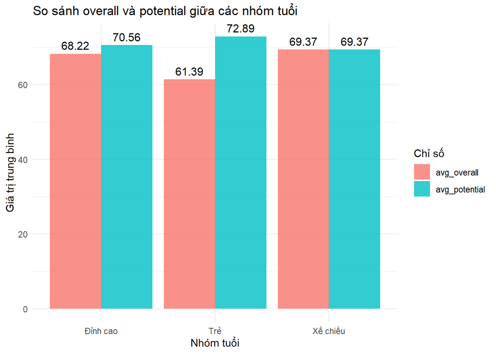

```r
data_age <- data |>
  mutate(
    age_group = case_when(
      age < 23 ~ "Trẻ",
      age >= 23 & age <= 30 ~ "Đỉnh cao",
      age > 30 ~ "Xế chiều"
    )
  )
data_age <- data_age |> relocate(age_group, .after = age)
summary_age_group <- data_age |>
  group_by(age_group) |>
  summarise(
    avg_overall = round(mean(overall), 2),
    avg_potential = round(mean(potential), 2),
    count = n()
  )

summary_long <- summary_age_group |>
  pivot_longer(cols = c(avg_overall, avg_potential), names_to = "metric", values_to = "value")

# Vẽ biểu đồ barplot
ggplot(summary_long, aes(x = age_group, y = value, fill = metric)) +
  geom_bar(stat = "identity", position = "dodge", alpha = 0.8) +
  geom_text(aes(label = round(value, 3)), position = position_dodge(width = 0.9), vjust = -0.5, color = "black", size = 4) +
  labs(
    title = "So sánh overall và potential giữa các nhóm tuổi", x = "Nhóm tuổi", y = "Giá trị trung bình", fill = "Chỉ số") +
  theme_minimal()
```

## Các cầu thủ trẻ tiềm năng không thi đấu cho các CLB “lớn”

### Định nghĩa các CLB lớn

```r
big_clubs <- c("FC Barcelona", "Real Madrid", "Manchester United", "FC Bayern München", "Liverpool",
               "Manchester City", "Paris Saint-Germain")
```

Các câu lạc bộ lớn ở đây được định nghĩa trên cảm tính

## Lọc ra cầu thủ trẻ tiềm năng không thuộc các CLB lớn

```r
young_potential_non_big_clubs <- data_age |>
  filter(age_group == "Trẻ", potential > 85, !club %in% big_clubs)
datatable(
  young_potential_non_big_clubs,
  options = list(scrollX = TRUE, scrollY = "400px", paging = FALSE, dom = 't')
)
```

|  | id | name | age | age_group | nationality | overall | potential | club | value | wage | preferred_foot | international_reputation | weak_foot | skill_moves | attacking_work_rate | deffensive_work_rate | body_type | position | jersey_number | joined | loaned_from | contract_valid_until | height | weight | crossing | finishing | heading_accuracy | short_passing | volleys | … |
| --- | --- | --- | --- | --- | --- | --- | --- | --- | --- | --- | --- | --- | --- | --- | --- | --- | --- | --- | --- | --- | --- | --- | --- | --- | --- | --- | --- | --- | --- | --- |
| 1 | 220793 | D. Sánchez | 22 | Trẻ | Colombia | 84 | 88 | Tottenham Hotspur | 34 | 105 | Right | 2 | 3 | 2 | Medium | High | Normal | Defender | 23 | 2017-08-26 | Not on loan | 2024-12-31 | 74 | 174 | 36 | 40 | 80 | 77 | 28 | … |
| 2 | 211117 | D. Alli | 22 | Trẻ | England | 84 | 90 | Tottenham Hotspur | 42.5 | 115 | Right | 3 | 3 | 4 | High | High | Lean | Midfielder | 20 | 2015-02-02 | Not on loan | 2024-12-31 | 74 | 176 | 69 | 83 | 77 | 85 | 79 | … |
| 3 | 213565 | T. Lemar | 22 | Trẻ | France | 83 | 89 | Atlético Madrid | 35.5 | 64 | Left | 3 | 2 | 4 | High | Medium | Lean | Midfielder | 8 | 2018-07-01 | Not on loan | 2023-12-31 | 67 | 137 | 83 | 75 | 54 | 84 | 78 | … |
| 4 | 213331 | J. Tah | 22 | Trẻ | Germany | 83 | 88 | Bayer 04 Leverkusen | 29.5 | 67 | Right | 2 | 4 | 2 | Medium | Medium | Stocky | Defender | 20 | 2015-07-16 | Not on loan | 2023-12-31 | 77 | 214 | 35 | 20 | 80 | 74 | 24 | … |
| 5 | 212188 | T. Werner | 22 | Trẻ | Germany | 83 | 87 | RB Leipzig | 34.5 | 70 | Right | 3 | 4 | 3 | High | Medium | Normal | Forward | 9 | 2016-07-01 | Not on loan | 2020-12-31 | 71 | 165 | 69 | 87 | 76 | 77 | 82 | … |
| 6 | 235243 | M. de Ligt | 18 | Trẻ | Netherlands | 82 | 91 | Ajax | 27 | 11 | Right | 2 | 4 | 2 | Medium | Medium | Normal | Defender | 3 | 2016-10-24 | Not on loan | 2021-12-31 | 74 | 196 | 57 | 53 | 81 | 75 | 40 | … |
| 7 | 231866 | Rodri | 22 | Trẻ | Spain | 82 | 87 | Atlético Madrid | 29 | 59 | Right | 1 | 3 | 4 | Medium | High | Lean | Midfielder | 16 | 2018-07-01 | Not on loan | 2023-12-31 | 75 | 181 | 63 | 64 | 75 | 83 | 59 | … |
| 8 | 230621 | G. Donnarumma | 19 | Trẻ | Italy | 82 | 93 | Milan | 29 | 23 | Right | 3 | 3 | 1 | Medium | Medium | Normal | Goalkeeper | 22 | 2015-07-01 | Not on loan | 2021-12-31 | 77 | 198 | 12 | 12 | 12 | 34 | 8 | … |
| 9 | 224411 | Gonçalo Guedes | 21 | Trẻ | Portugal | 82 | 86 | Valencia CF | 29 | 36 | Right | 1 | 3 | 4 | High | Low | Normal | Midfielder | 17 | 2018-08-29 | Not on loan | 2024-12-31 | 70 | 150 | 76 | 75 | 60 | 77 | 71 | … |
| 10 | 223959 | L. Torreira | 22 | Trẻ | Uruguay | 82 | 87 | Arsenal | 25 | 98 | Right | 2 | 3 | 3 | Medium | High | Normal | Midfielder | 14 | 2018-07-12 | Not on loan | 2023-12-31 | 66 | 141 | 74 | 50 | 55 | 83 | 65 | … |

[output cut: 85 more lines]

Bảng phía trên là danh sách các cầu thủ trẻ dưới 23 tuổi, có tiềm năng với chỉ số potential lớn hơn 85, quan trọng nhất là họ không thi đấu cho các câu lạc bộ lớn. Do đó các câu lạc bộ lớn có thể để mắt đến các cầu thủ này.

# A/B Testing

Load Sport Data Analysis đã được làm sạch

```r
data <- read_csv(file = "cleaned_fifa_eda_stats.csv")
data <- data |> clean_names()
```

Thống kê đơn giản dụa trên vị trí cầu thủ

```r
data |>
  group_by(position) |>
  summarise(
    n = n(),
    m_wage = mean(wage, na.rm = TRUE),
    sd_wage = sd(wage, na.rm = TRUE),
    m_overall = mean(overall, na.rm = TRUE),
    sd_overall = sd(overall, na.rm = TRUE),
    m_potential = mean(potential, na.rm = TRUE),
    sd_potential = sd(potential, na.rm = TRUE),
    m_value = mean(value, na.rm = TRUE),
    sd_value = sd(value, na.rm = TRUE)
  )
```

```
## # A tibble: 4 × 10
##   position       n m_wage sd_wage m_overall sd_overall m_potential sd_potential
##   <chr>      <int>  <dbl>   <dbl>     <dbl>      <dbl>       <dbl>        <dbl>
## 1 Defender    5438   9.19    19.4      66.4       6.53        70.9         5.83
## 2 Forward     3044  11.4     29.5      66.3       7.16        71.6         6.23
## 3 Goalkeeper  1900   6.73    16.9      64.5       7.66        69.6         6.35
## 4 Midfielder  6261   9.97    21.8      66.5       7.06        71.6         6.24
## # ℹ 2 more variables: m_value <dbl>, sd_value <dbl>
```

Chạy biểu đồ so sánh phân phối về mức wage, potential, value, overrall

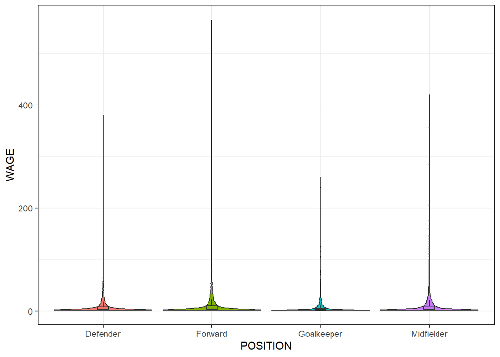

```r
ggplot(data, aes(x = position, y = wage, fill = position)) +
  geom_violin(scale = "width") +
  geom_boxplot(width = 0.1, outlier.shape = NA) +
  labs(x = "POSITION", y = "WAGE") +
  theme_bw() +
  theme(legend.position = "none")
```

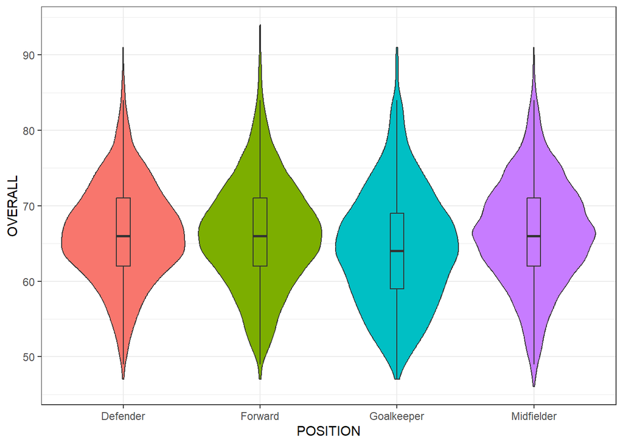

```r
ggplot(data, aes(x = position, y = overall, fill = position)) +
  geom_violin(scale = "width") +
  geom_boxplot(width = 0.1, outlier.shape = NA) +
  labs(x = "POSITION", y = "OVERALL") +
  theme_bw() +
  theme(legend.position = "none")
```

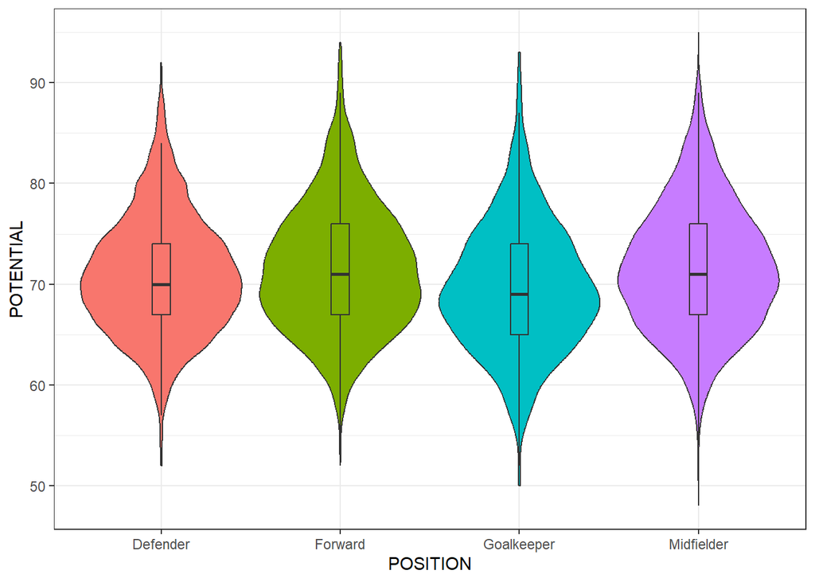

```r
ggplot(data, aes(x = position, y = potential, fill = position)) +
  geom_violin(scale = "width") +
  geom_boxplot(width = 0.1, outlier.shape = NA) +
  labs(x = "POSITION", y = "POTENTIAL") +
  theme_bw() +
  theme(legend.position = "none")
```

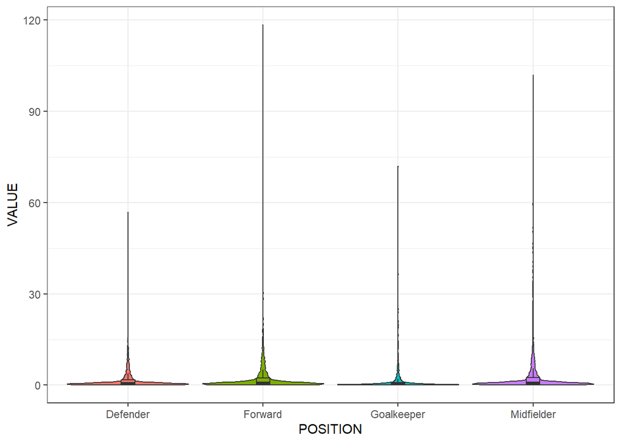

```r
ggplot(data, aes(x = position, y = value, fill = position)) +
  geom_violin(scale = "width") +
  geom_boxplot(width = 0.1, outlier.shape = NA) +
  labs(x = "POSITION", y = "VALUE") +
  theme_bw() +
  theme(legend.position = "none")
```

##Nhận xét## Dự đoán các dự liệu cho rằng mức lương ở các vị trí đều tương đương nhau, tuy nhiên chưa rõ nên chạy Anova

```r
library(lmPerm)
set.seed(19)
```

Anova giữa các position và 4 biến wage, overall, potential, value H0: Các giá trị giữa các position là như nhau H1: Các giả trị giữa các position là khác nhau

```r
anova_po_wage <- aovp(formula = wage~position, data = data, perm="Prob")
```

```
## [1] "Settings:  unique SS "
```

```r
summary(anova_po_wage)
```

```
## Component 1 :
##                Df R Sum Sq R Mean Sq Iter  Pr(Prob)
## position1       3    27848    9282.6 5000 < 2.2e-16 ***
## Residuals   16639  8220997     494.1
## ---
## Signif. codes:  0 '***' 0.001 '**' 0.01 '*' 0.05 '.' 0.1 ' ' 1
```

```r
anova_po_overall <- aovp(formula = overall~position, data = data, perm="Prob")
```

```
## [1] "Settings:  unique SS "
```

```r
summary(anova_po_overall)
```

```
## Component 1 :
##                Df R Sum Sq R Mean Sq Iter  Pr(Prob)
## position1       3     6277   2092.31 5000 < 2.2e-16 ***
## Residuals   16639   811101     48.75
## ---
## Signif. codes:  0 '***' 0.001 '**' 0.01 '*' 0.05 '.' 0.1 ' ' 1
```

```r
anova_po_potential <- aovp(formula = potential~position, data = data, perm="Prob")
```

```
## [1] "Settings:  unique SS "
```

```r
summary(anova_po_potential)
```

```
## Component 1 :
##                Df R Sum Sq R Mean Sq Iter  Pr(Prob)
## position1       3     6591   2196.92 5000 < 2.2e-16 ***
## Residuals   16639   623140     37.45
## ---
## Signif. codes:  0 '***' 0.001 '**' 0.01 '*' 0.05 '.' 0.1 ' ' 1
```

```r
anova_po_value <- aovp(formula = value~position, data = data, perm="Prob")
```

```
## [1] "Settings:  unique SS "
```

```r
summary(anova_po_value)
```

```
## Component 1 :
##                Df R Sum Sq R Mean Sq Iter  Pr(Prob)
## position1       3     4114   1371.49 5000 < 2.2e-16 ***
## Residuals   16639   540505     32.48
## ---
## Signif. codes:  0 '***' 0.001 '**' 0.01 '*' 0.05 '.' 0.1 ' ' 1
```

So sánh giá trị p.value, ta đưa ra kết luận (do chạy knit khá lâu nên kết quả được để ở html và báo cáo)

Kiểm định độc lập các nhóm định tính trong bài với độ tin cậy là 0.05 Biến được kiểm định ở đây là position với các biến định tính khác bao gồm: - international_reputation - attacking_work_rate - deffensive_work_rate - body_type Đầu tiên là giữa position và international_reputation H0: Vị trí của cầu thủ không liên quan đến danh tiếng quốc tế H1: Vị trí của cầu thủ liên quan đến danh tiếng quốc tế

```r
repu_position <- table(data$international_reputation, data$position)
repu_position_test <- chisq.test(repu_position)
cat("\nExpected Frequencies: position and và international_reputation \n")
```

```
##
## Expected Frequencies: position and và international_reputation
```

```r
repu_position_test$expected
```

```
##
##        Defender     Forward   Goalkeeper  Midfielder
##   1 4947.230547 2769.284624 1728.5285105 5695.956318
##   2  377.062549  211.066274  131.7430752  434.128102
##   3   95.735985   53.589617   33.4494983  110.224899
##   4   16.010455    8.962086    5.5939434   18.433516
##   5    1.960464    1.097398    0.6849727    2.257165
```

```r
cat("Observed p-value:", repu_position_test$p.value, "\n")
```

```
## Observed p-value: 2.397757e-05
```

Ở bảng tần số kỳ vọng ta thu được tần số kỳ vọng nhỏ hơn 5 nên kiểm định có thể không chính xác => Áp dụng phương pháp lấy lại mẫu

```r
n_permutations <- 1000
permutation_stats <- numeric(n_permutations)
```

```r
for (i in 1:n_permutations) {
  permuted_repu <- sample(data$international_reputation)
  permuted_table <- table(data$position, permuted_repu)
  permuted_result <- chisq.test(permuted_table)
  permutation_stats[i] <- permuted_result$statistic
}
```

```r
# Tính p-value
observed_stat <- repu_position_test$statistic
p_value_permutation <- mean(permutation_stats >= observed_stat)
cat("p-value:", p_value_permutation, "\n")
```

```
## p-value: 0
```

Vậy ta bác bỏ H0 => Vị trí cầu thủ có liên quan đến danh tiếng quốc tế

Kế đến ta kiểm định độc lập position vs attacking_work_rate Ho: Vị trí không liên quan đến attacking_work_rate H1: Vị trí liên quan đến attacking_work_rate

```r
# chisquare position vs attacking_work_rate
po_attack <- table(data$attacking_work_rate, data$position)
po_attack_test <- chisq.test(po_attack)
cat("\nExpected Frequencies: position and ̀attacking_work_rate \n")
```

```
##
## Expected Frequencies: position and ̀attacking_work_rate
```

```r
po_attack_test$expected
```

```
##
##           Defender   Forward Goalkeeper Midfielder
##   High   1450.0898  811.7089  506.65145  1669.5498
##   Low     276.0987  154.5503   96.46698   317.8841
##   Medium 3711.8116 2077.7408 1296.88157  4273.5661
```

```r
cat("Observed p-value:", po_attack_test$p.value, "\n")
```

```
## Observed p-value: 0
```

Vậy ta bác bỏ H0 => Vị trí cầu thủ có liên quan đến attack_working_rate

Ho: Vị trí không liên quan đến deffensive_work_rate H1: Vị trí liên quan đến deffensive_work_rate

```r
# chisquare position vs deffensive_work_rate
po_defensive <- table(data$deffensive_work_rate, data$position)
po_defensive_test <- chisq.test(po_defensive)
cat("\nExpected Frequencies: position and deffensive_work_rate \n")
```

```
##
## Expected Frequencies: position and deffensive_work_rate
```

```r
po_defensive_test$expected
```

```
##
##           Defender   Forward Goalkeeper Midfielder
##   High    949.8447  531.6895   331.8693  1093.5965
##   Low     463.3230  259.3518   161.8819   533.4434
##   Medium 4024.8323 2252.9587  1406.2489  4633.9601
```

```r
cat("Observed p-value:", po_defensive_test$p.value, "\n")
```

```
## Observed p-value: 0
```

Vậy ta bác bỏ H0 => Vị trí cầu thủ có liên quan deffensive_working_rate

Ho: Vị trí không liên quan đến body_type H1: Vị trí liên quan đến body_type

```r
# chisquare position vs body_type
po_body <- table(data$body_type, data$position)
po_body_test <- chisq.test(po_body)
cat("\nExpected Frequencies: position and body_type \n")
```

```
##
## Expected Frequencies: position and body_type
```

```r
po_body_test$expected
```

```
##
##           Defender   Forward Goalkeeper Midfielder
##   Lean   1914.0662 1071.4265   668.7616  2203.7456
##   Normal 3180.5259 1780.3459  1111.2540  3661.8743
##   Stocky  343.4079  192.2276   119.9844   395.3801
```

```r
cat("Observed p-value:", po_body_test$p.value, "\n")
```

```
## Observed p-value: 3.029882e-68
```

Vậy ta bác bỏ H0 => Vị trí cầu thủ có liên quan đến body_type

Ta kiểm thử với body_type xem có ảnh hưởng đến yếu tố tấn công hay phòng thủ không Ho: body_type không liên quan đến attack_work_rate H1: body_type liên quan đến body_type

```r
# chisquare body_type vs attacking_work_rate
body_attack <- table(data$body_type, data$attacking_work_rate)
body_attack_test <- chisq.test(body_attack)
cat("\nExpected Frequencies: body_type and attacking_work_rate \n")
```

```
##
## Expected Frequencies: body_type and attacking_work_rate
```

```r
body_attack_test$expected
```

```
##
##               High       Low    Medium
##   Lean   1562.0864 297.42294 3998.4907
##   Normal 2595.6554 494.21559 6644.1291
##   Stocky  280.2582  53.36147  717.3803
```

```r
cat("Observed p-value:", body_attack_test$p.value, "\n")
```

```
## Observed p-value: 5.462144e-13
```

Vậy ta bác bỏ H0 => body_type có liên quan đến attacking_work_rate

Ho: body_type không liên quan đến defensive_work_rate H1: body_type liên quan đến defensive_work_rate

```r
# chisquare body_type vs defensive_work_rate
body_def <- table(data$body_type, data$deffensive_work_rate)
body_def_test <- chisq.test(body_def)
cat("\nExpected Frequencies: body_type and deffensive_work_rate \n")
```

```
##
## Expected Frequencies: body_type and deffensive_work_rate
```

```r
body_def_test$expected
```

```
##
##               High       Low    Medium
##   Lean   1023.2053 499.10737 4335.6873
##   Normal 1700.2186 829.34639 7204.4350
##   Stocky  183.5761  89.54624  777.8777
```

```r
cat("Observed p-value:", body_def_test$p.value, "\n")
```

```
## Observed p-value: 1.098452e-10
```

Vậy ta bác bỏ H0 => body_type có liên quan đến deffensive_work_rate

##age Kế đến, em muốn xem thử độ tuổi có ảnh hương đến các yếu tố khác hay không, đặc biệt là 4 yếu tố wage, potential, overall, value Trước hết tạo một biến mới là year_old gồm 2 giá trị là old(trên hoặc b̀ăng 30) và young(dưới 30)

```r
data$year_old <- ifelse(data$age >= 30, "old", "young")

# Tạo hàm permutation để kiểm định
perm_fun <- function(x, nA, nB, R) {
  n <- nA + nB
  mean_diff <- numeric(R)
  for (i in 1:R){
    idx_a <- sample(x = 1:n, size = nA)
    idx_b <- setdiff(x = 1:n, y = idx_a)
    mean_diff[i] <- mean(x[idx_a]) - mean(x[idx_b])
  }
  return(mean_diff)
}

set.seed(19)
data |>
  group_by(year_old) |>
  summarise(
    n = n(),
    m_wage = mean(wage, na.rm = TRUE),
    sd_wage = sd(wage, na.rm = TRUE),
    m_overall = mean(overall, na.rm = TRUE),
    sd_overall = sd(overall, na.rm = TRUE),
    m_potential = mean(potential, na.rm = TRUE),
    sd_potential = sd(potential, na.rm = TRUE),
    m_value = mean(value, na.rm = TRUE),
    sd_value = sd(value, na.rm = TRUE)
  )
```

```
## # A tibble: 2 × 10
##   year_old     n m_wage sd_wage m_overall sd_overall m_potential sd_potential
##   <chr>    <int>  <dbl>   <dbl>     <dbl>      <dbl>       <dbl>        <dbl>
## 1 old       3352  12.8     28.4      69.5       5.68        69.5         5.68
## 2 young    13291   8.81    20.3      65.3       7.07        71.6         6.19
## # ℹ 2 more variables: m_value <dbl>, sd_value <dbl>
```

Với Potential và Value, độ tin cậy 0.05 Ho: Nhóm old và young bằng nhau H1: Nhóm old thấp hơn nhóm young

```r
#  potential
diff_mean_potential <- perm_fun(data$potential, nA = 3352, nB = 13291, R = 1000)
mean_a_potential <- mean(data$potential[data$year_old == 'old'])
mean_b_potential <- mean(data$potential[data$year_old == 'young'])
p_value_potential <- mean(diff_mean_potential < (mean_a_potential - mean_b_potential))

#  value
diff_mean_value <- perm_fun(data$value, nA = 3352, nB = 13291, R = 1000)
mean_a_value <- mean(data$value[data$year_old == 'old'])
mean_b_value <- mean(data$value[data$year_old == 'young'])
p_value_value <- mean(diff_mean_value < (mean_a_value - mean_b_value))

cat("P-value for potential:", p_value_potential)
```

```
## P-value for potential: 0
```

```r
cat("\nP-value for value:", p_value_value)
```

```
##
## P-value for value: 0.308
```

Như vậy ta bác bỏ H0 cho potential => Chỉ số potential của nhóm old thấp hơn nhóm young Như vậy ta không bác bỏ H0 cho value => Chỉ số value của nhóm old và nhóm young như nhau

Với Overall và Wage, độ tin cậy 0.05 Ho: Nhóm old và young bằng nhau H1: Nhóm old cao hơn nhóm young

```r
# overall
diff_mean_perm <- perm_fun(data$overall, nA = 3352, nB = 13291, R = 1000)
mean_a <- mean(data$overall[data$year_old == 'old'])
mean_b <- mean(data$overall[data$year_old == 'young'])
p_value_overall <- mean(diff_mean_perm > (mean_a - mean_b))

#  wage
diff_mean_wage <- perm_fun(data$wage, nA = 3352, nB = 13291, R = 1000)
mean_a_wage <- mean(data$wage[data$year_old == 'old'])
mean_b_wage <- mean(data$wage[data$year_old == 'young'])
p_value_wage <- mean(diff_mean_wage > (mean_a_wage - mean_b_wage))

# p-value
cat("P-value for overall:", p_value_potential)
```

```
## P-value for overall: 0
```

```r
cat("\nP-value for wage:", p_value_wage)
```

```
##
## P-value for wage: 0
```

Như vậy ta bác bỏ H0 cho overall và cả wage => Chỉ số overall và wage của nhóm old cao hơn nhóm young

Ngoài 4 biến trên thì ta thực hiện đồng loạt permutation test với những biến định lượng còn lại để xem giữa old và young thì sẽ có những đặc tính nào khác biệt H0: Đặc tính này giống nhau giữa old và young H1: Đặc tính này có sự khác nhau giưa old và young Thực hiện với độ tin cây 0.05

```r
# List of features for A/B testing
features <- c('crossing', 'finishing', 'heading_accuracy', 'short_passing', 'volleys',
              'dribbling', 'curve', 'fk_accuracy', 'long_passing', 'ball_control',
              'acceleration', 'sprint_speed', 'agility', 'reactions', 'balance',
              'shot_power', 'jumping', 'stamina', 'strength', 'long_shots',
              'aggression', 'interceptions', 'positioning', 'vision', 'penalties',
              'composure', 'marking', 'standing_tackle', 'sliding_tackle',
              'gk_diving', 'gk_handling', 'gk_kicking', 'gk_positioning', 'gk_reflexes')


# A/B testing for each feature

perm_results <- data.frame(Feature = features, p_value = NA, conclusion = NA)

for (feature in features) {
  # Chia ra
  old <- data[data$year_old == 'old', feature]
  young <- data[data$year_old == 'young', feature]
  # Dem phan tu
  nnA=nrow(old)
  nnB=nrow(young)

  diff_mean_perm <- perm_fun(data[[feature]], nA = nnA, nB = nnB, R = 1000)
  p_value <- mean(abs(diff_mean_perm) >= abs(mean(old[[feature]]) - mean(young[[feature]])))
  perm_results[perm_results$Feature == feature, 'p_value'] <- p_value
  perm_results[perm_results$Feature == feature, 'conclusion'] <- ifelse(p_value < 0.05, "H1", "H0")
}


perm_results
```

```
##             Feature p_value conclusion
## 1          crossing   0.000         H1
## 2         finishing   0.008         H1
## 3  heading_accuracy   0.000         H1
## 4     short_passing   0.000         H1
## 5           volleys   0.000         H1
## 6         dribbling   0.000         H1
## 7             curve   0.000         H1
## 8       fk_accuracy   0.000         H1
## 9      long_passing   0.000         H1
## 10     ball_control   0.084         H0
## 11     acceleration   0.000         H1
## 12     sprint_speed   0.000         H1
## 13          agility   0.000         H1
## 14        reactions   0.000         H1
```

[output cut: 20 more lines]

Nhận xét, đa phần đều khác nhau giữa old và young trong các đặc tính, riêng ball_control thì vẫn giống nhau, như vậy ta có thể nhận xét rằng khi cần chiêu mộ một cầu thủ thì yếu tố ball_control không nằm trong xét duyệt khi phân tích giữa old và young

Ta phân tích về các cầu thủ ở giữa các vùng Tạo một thuộc tính mới về các vùng của các cầu thủ, to dùng thêm tập data_continents để xác định vùng

```r
data_continents <- read_csv(file = "Countries by continents.csv")
data_continents <- data_continents |> clean_names()
colnames(data_continents)[colnames(data_continents) == 'country'] <- 'nationality'
```

```r
data <- merge(data, data_continents[, c('nationality', 'continent')], by = 'nationality', all.x = TRUE)
```

```r
colnames(data)[colnames(data) == 'continent'] <- 'region'
```

Ta thống kê cơ bản các vùng theo các biến wage,overall,potential,value

```r
data |>
  group_by(region) |>
  summarise(
    n = n(),
    m_wage = mean(wage, na.rm = TRUE),
    sd_wage = sd(wage, na.rm = TRUE),
    m_overall = mean(overall, na.rm = TRUE),
    sd_overall = sd(overall, na.rm = TRUE),
    m_potential = mean(potential, na.rm = TRUE),
    sd_potential = sd(potential, na.rm = TRUE),
    m_value = mean(value, na.rm = TRUE),
    sd_value = sd(value, na.rm = TRUE)
  )
```

```
## # A tibble: 6 × 10
##   region          n m_wage sd_wage m_overall sd_overall m_potential sd_potential
##   <chr>       <int>  <dbl>   <dbl>     <dbl>      <dbl>       <dbl>        <dbl>
## 1 Africa       1092  11.2    20.6       68.1       5.86        72.5         5.55
## 2 Asia         1603   3.84    6.53      62.4       6.07        66.6         5.56
## 3 Europe       9956  10.4    23.5       66.1       7.19        71.5         6.21
## 4 North Amer…   877   6.37   11.8       65.3       5.84        70.6         5.30
## 5 Oceania       261   3.60    7.33      62.6       6.06        68.2         4.38
## 6 South Amer…  2854  11.2    26.4       68.3       6.57        72.3         5.59
## # ℹ 2 more variables: m_value <dbl>, sd_value <dbl>
```

Dù rằng ta thấy rõ có sự khác biệt rõ rệt ở biến wage và value giữa các châu lục, vấn đề này có thể liên quan đến kinh tế giữa các châu lục nên mới có sự phân biệt rõ rệt như vậy

Ta dùng đồ thị để biểu diễn thử dữ liệu

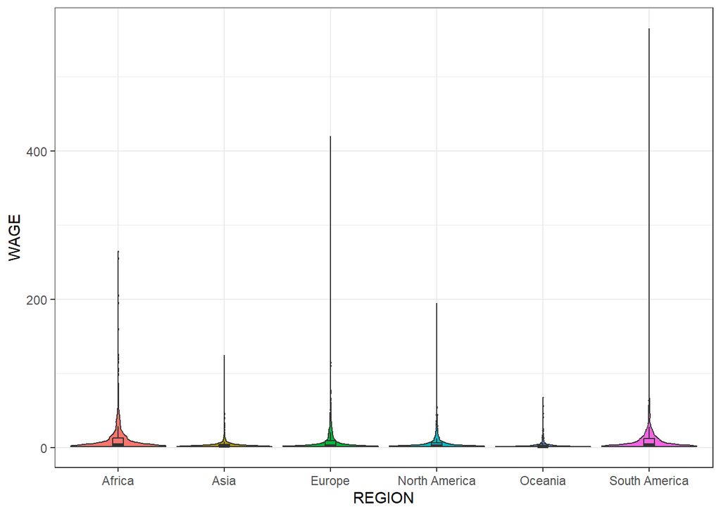

```r
ggplot(data, aes(x = region, y = wage, fill = region)) +
  geom_violin(scale = "width") +
  geom_boxplot(width = 0.1, outlier.shape = NA) +
  labs(x = "REGION", y = "WAGE") +
  theme_bw() +
  theme(legend.position = "none")
```

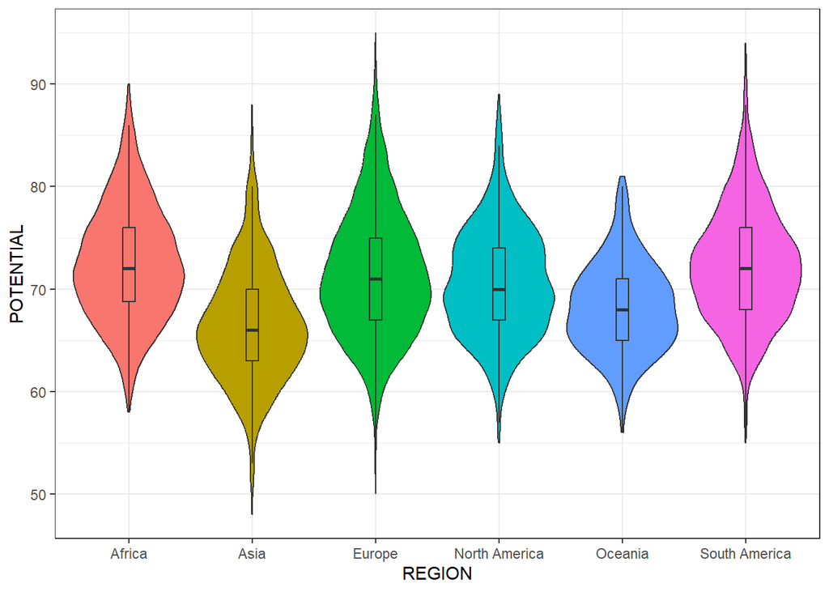

```r
ggplot(data, aes(x = region, y = potential, fill = region)) +
  geom_violin(scale = "width") +
  geom_boxplot(width = 0.1, outlier.shape = NA) +
  labs(x = "REGION", y = "POTENTIAL") +
  theme_bw() +
  theme(legend.position = "none")
```

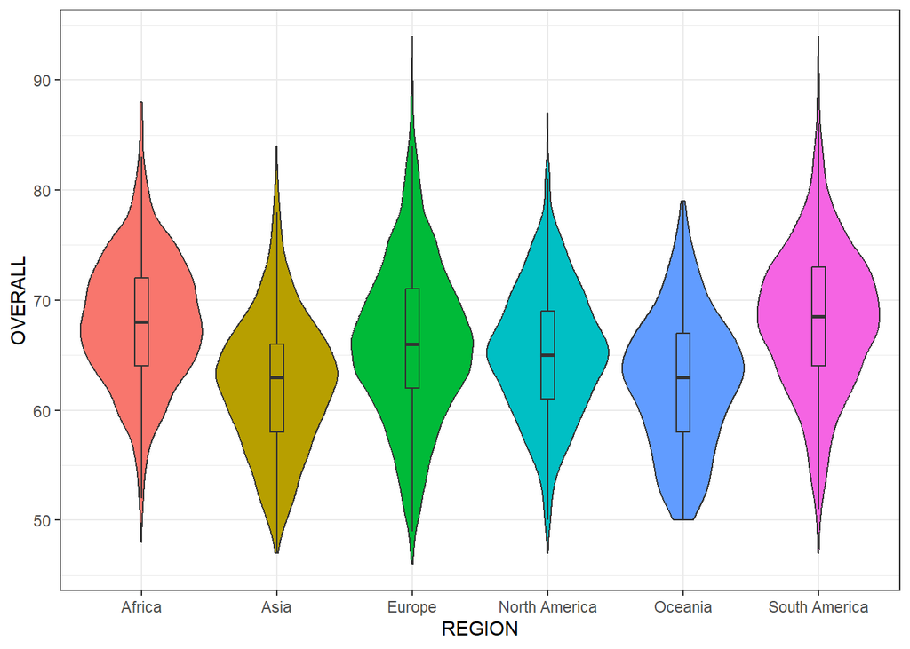

```r
ggplot(data, aes(x = region, y = overall, fill = region)) +
  geom_violin(scale = "width") +
  geom_boxplot(width = 0.1, outlier.shape = NA) +
  labs(x = "REGION", y = "OVERALL") +
  theme_bw() +
  theme(legend.position = "none")
```

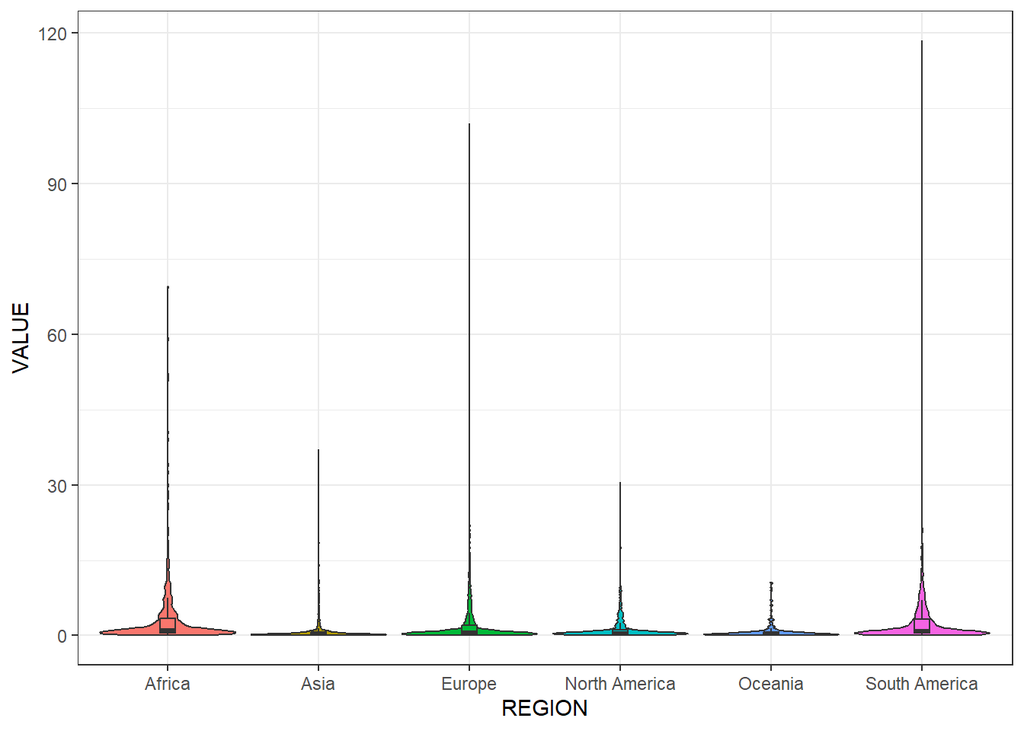

```r
ggplot(data, aes(x = region, y = value, fill = region)) +
  geom_violin(scale = "width") +
  geom_boxplot(width = 0.1, outlier.shape = NA) +
  labs(x = "REGION", y = "VALUE") +
  theme_bw() +
  theme(legend.position = "none")
```

Với overall và potential, để biết chắc chắn thì nên dùng anova Ho: overall giữa các châu lục giống nhau H1: overall giữa các châu lục khác nhau Với độ tin cậy 0.05, dưa vào p.value để đưa ra kết luận (do thời gian knit lâu nên kết luận ghi ở báo cáo)

```r
anova_re_overall <- aovp(formula = overall~region, data = data, perm="Prob")
```

```
## [1] "Settings:  unique SS "
```

```r
summary(anova_re_overall)
```

```
## Component 1 :
##                Df R Sum Sq R Mean Sq Iter  Pr(Prob)
## region1         5    43552    8710.4 5000 < 2.2e-16 ***
## Residuals   16637   773826      46.5
## ---
## Signif. codes:  0 '***' 0.001 '**' 0.01 '*' 0.05 '.' 0.1 ' ' 1
```

```r
anova_re_potential <- aovp(formula = potential~region, data = data, perm="Prob")
```

```
## [1] "Settings:  unique SS "
```

```r
summary(anova_re_potential)
```

```
## Component 1 :
##                Df R Sum Sq R Mean Sq Iter  Pr(Prob)
## region1         5    43696    8739.2 5000 < 2.2e-16 ***
## Residuals   16637   586035      35.2
## ---
## Signif. codes:  0 '***' 0.001 '**' 0.01 '*' 0.05 '.' 0.1 ' ' 1
```

Nhóm muốn tìm hiểu ở Asia và South America tại sao lại có sự khác nhau rõ rệt như vậy, chạy permutation test ở các biến định lượng khác để xem rõ sự khác biệt và xem Asia đang có chí số ít hơn South America ở những tính chất nào H0: Đặc tính này giống nhau giữa South America và Asia H1: Đặc tính này của South America tốt hơn Asia Độ tin cậy là 0.05

```r
## So sanh giua asia va south america
samerica_asia <- subset(data, region %in% c("South America", "Asia"))
samerica_asia <- samerica_asia |> clean_names()


features <- c('crossing', 'finishing', 'heading_accuracy', 'short_passing', 'volleys',
              'dribbling', 'curve', 'fk_accuracy', 'long_passing', 'ball_control',
              'acceleration', 'sprint_speed', 'agility', 'reactions', 'balance',
              'shot_power', 'jumping', 'stamina', 'strength', 'long_shots',
              'aggression', 'interceptions', 'positioning', 'vision', 'penalties',
              'composure', 'marking', 'standing_tackle', 'sliding_tackle',
              'gk_diving', 'gk_handling', 'gk_kicking', 'gk_positioning', 'gk_reflexes')


# Initialize result storage
perm_results <- data.frame(Feature = features, p_value = NA, conclusion = NA)

for (feature in features) {
  # Chia ra
  samerica <- samerica_asia[samerica_asia$region == 'South America', feature]
  asia <- samerica_asia[samerica_asia$region == 'Asia', feature]
  # Dem phan tu
  nnA=length(samerica)
  nnB=length(asia)

  diff_mean_perm <- perm_fun(samerica_asia[[feature]], nA = nnA, nB = nnB, R = 1000)
  p_value <- mean(diff_mean_perm >= mean(samerica) - mean(asia))
  perm_results[perm_results$Feature == feature, 'p_value'] <- p_value
  perm_results[perm_results$Feature == feature, 'conclusion'] <- ifelse(p_value < 0.05, "H1", "H0")
}

perm_results
```

```
##             Feature p_value conclusion
## 1          crossing   0.000         H1
## 2         finishing   0.000         H1
## 3  heading_accuracy   0.000         H1
## 4     short_passing   0.000         H1
## 5           volleys   0.000         H1
## 6         dribbling   0.000         H1
## 7             curve   0.000         H1
## 8       fk_accuracy   0.000         H1
## 9      long_passing   0.000         H1
## 10     ball_control   0.000         H1
## 11     acceleration   0.000         H1
## 12     sprint_speed   0.000         H1
## 13          agility   0.000         H1
## 14        reactions   0.000         H1
```

[output cut: 20 more lines]

Qua bảng trên ta thấy đa phần đểu H1, chỉ ra được Asia một châu lục còn chưa qua nổi trội về bóng đá đang thiếu những gì để có thể trỗi dậy mạnh hơn vươn tới South America một châu lục cực kì nổi trội